# Lab 1: Generalize Fast!

Replication data from experiment: *Social Competition Drives Collective Action to Reduce Informal Waste Burning in Uganda

EDS 241

2025-01-05

### Figure: Map of Treatment Assignment Zones in Nansana, Uganda

```
* SOURCE: Figure from Buntaine et al., 2024 (S5; Supplemental Materials)
```

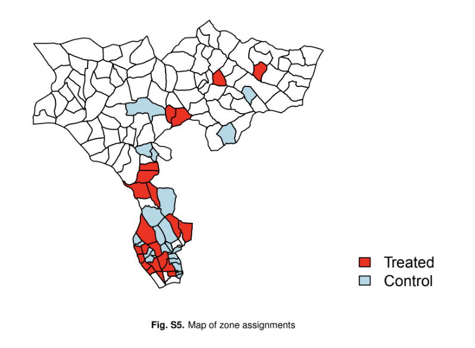

### Open source data & applied study:

Open access data was utilized for this class exercise from the study (Buntaine et al., 2024):

> Buntaine, M. T., Komakech, P., & Shen, S. V. (2024). *Social competition drives collective action to reduce informal waste burning in Uganda*. Proceedings of the National Academy of Sciences, 121(23). https://doi.org/10.1073/pnas.2319712121

### Outline - What are the goals of this exercise?

#### 1. Start with a simple OLS model

#### 2. Demonstrate the rationale for estimating progressively complex models

#### 3. Illustrate a causal inference approach (i.e., identify `robust` estimators)

#### 4. Conclusion: What is the take-home message of the Lab-1 exercise? . . .

```
Estimating complex models is a relatively easy part of our work as data scientists...

* Making informed specification decisions & communicating results is the hard part
(i.e., the science side of `data science`)!
```

In this tutorial I use `this text style` to highlight:

- Statistical jargon - E.g., `Ordinary Least Squares (OLS)`
- Variable names - E.g., `predictor_x`
- In-text R code - E.g., `here::here()`

### Let’s get started!

```r
library(tidyverse)   # Keeping things tidy (https://www.tidyverse.org/packages/)
library(janitor)     # Housekeeping (https://cran.r-project.org/web/packages/janitor/vignettes/janitor.html)
library(here)        # Location, location, location (https://here.r-lib.org/)
library(jtools)      # Pretty regression output (https://jtools.jacob-long.com/)
library(gt)          # Tables (https://gt.rstudio.com/)
library(gtsummary)   # Table for checking balance (https://www.danieldsjoberg.com/gtsummary/)
library(performance) # Check model diagnostics (https://easystats.github.io/performance/index.html)
```

### Getting to know our data example - analysis variables

```r
variable_descriptions <- tribble(
  ~"Label", ~"Description",
 #----------|-------------|,
  "zoneid" , "Zone or neighborhood ID: The observational unit (N=44)",
  "waste_piles" , "The outcome variable (Y): The number of waste pile burns recorded (Range; 5, 125)",
  "treat" , "The treatment assignment variable (0 = Control Group; 1 = Treatment Group)"
 )

gt(variable_descriptions) %>%
    tab_header(
        title = "Focal Variables - Evaluating Treatment Effects") %>%
    tab_style(
      style = cell_text(weight = "bold"),
      locations = cells_column_labels())
```

Focal Variables - Evaluating Treatment Effects

| Label | Description |
| --- | --- |
| zoneid | Zone or neighborhood ID: The observational unit (N=44) |
| waste_piles | The outcome variable (Y): The number of waste pile burns recorded (Range; 5, 125) |
| treat | The treatment assignment variable (0 = Control Group; 1 = Treatment Group) |

### Read in the Nansana experiment data (Buntaine et al., 2024)

```r
#waste pile count data:
counts_gpx <- read_csv(here("data", "waste_pile_counts_gpx.csv")) %>%
    rename("waste_piles" = "total",
           "rain_0_48hrs" = "rf_0_to_48_hours",
           "rain_49_168hrs" = "rf_49_to_168_hours") %>%
    filter(survey%in%c(
      "post_treatment_1","post_treatment_2","post_treatment_3",
      "post_treatment_4","post_treatment_5"))

#select subset of post-treatment periods (remove time point 5):
post_treat_subset <- counts_gpx %>%
   filter(survey == "post_treatment_4")
```

### Model 1: Simple OLS estimator

Review of regression: Ordinary Least Squares (OLS)

```r
m1_ols <- lm(
    waste_piles ~ treat,
    data = post_treat_subset)

summ(m1_ols, model.fit = FALSE)
```

| Observations | 44 |
| --- | --- |
| Dependent variable | waste_piles |
| Type | OLS linear regression |

|  | Est. | S.E. | t val. | p |
| --- | --- | --- | --- | --- |
| (Intercept) | 77.91 | 4.16 | 18.73 | 0.00 |
| treat | -24.77 | 5.88 | -4.21 | 0.00 |

Standard errors: OLS

### Are we making reasonable assumptions?

```
Let's take a quick look at our outcome variable `waste piles`!
```

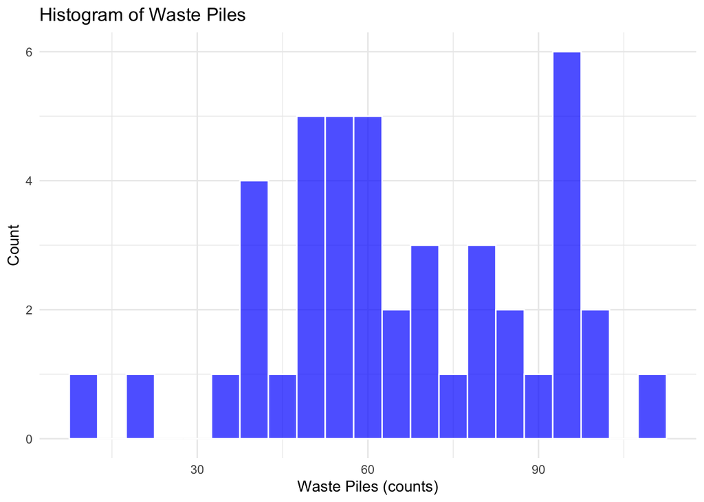

```r
post_treat_subset %>%
  ggplot(aes(x = waste_piles)) +
  geom_histogram(binwidth = 5, fill = "blue", color = "white", alpha = 0.7) +
  labs(title = "Histogram of Waste Piles",
    x = "Waste Piles (counts)",
    y = "Count") +
    theme_minimal()
```

### Check model assumption: normality of residuals

Make a QQ plot displaying residuals (y-axis) compared to the normal distribution (x-axis)

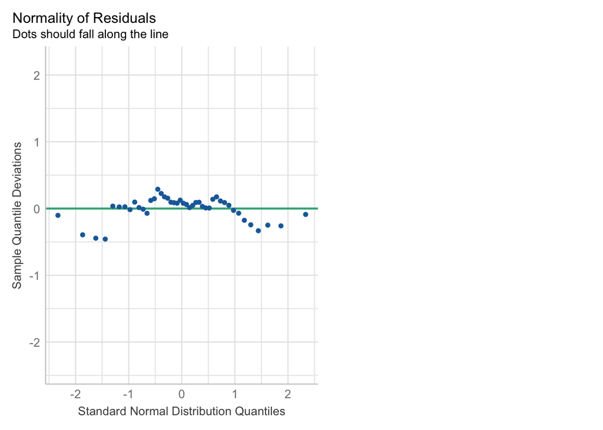

```r
check_model(m1_ols,  check = "qq" )
```

**Key takeaways:**

- Hmmm… our outcome is a count variable
- Is the OLS assumption, *normality of residuals*, a good fit for the data?
- Probably not, let’s do away with normality!

### Relax- time to generalize!

- We can `relax` the normality assumption
- The outcome `waste_piles` is a `count variable`, not a true continuous variable
- We can try out a common estimator used for count outcomes, `Poisson regression`
- Let’s estimate a `Generalized Linear Model (GLM)`

### Model 2: Poisson Generalized Linear Regression Model

- Poisson regression explicitly models the outcome as a count variable
- Assumes `Y` follows a Poisson distribution with non-negative integers (counts!)
- Poisson regression makes an additional assumption- that variance (`dispersion`) is proportional to the mean

  Does the data match the theoretical distribution proposed?

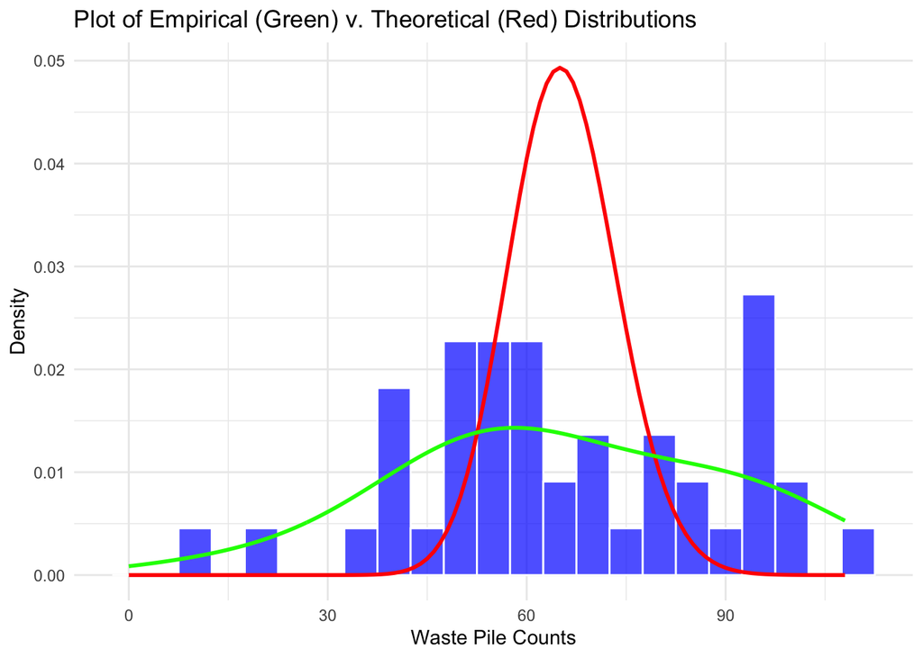

```r
lambda_hat <- mean(post_treat_subset$waste_piles)

poisson_curve <- tibble(
  x = seq(0, max(post_treat_subset$waste_piles), by = 1),  # Range of x values
  density = dpois(seq(0, max(post_treat_subset$waste_piles), by = 1),
                  lambda = mean(post_treat_subset$waste_piles))
)

ggplot(post_treat_subset, aes(x = waste_piles)) +
  geom_histogram(aes(y = ..density..), binwidth = 5, color = "white", fill = "blue", alpha = 0.7) +
  geom_line(data = poisson_curve, aes(x = x, y = density), color = "red", size = 1) +  # Poisson curve
  geom_density(color = "green", size = 1, adjust = 1.5) +  # KDE for a smoother curve
  labs(
    title = "Plot of Empirical (Green) v. Theoretical (Red) Distributions",
    x = "Waste Pile Counts",
    y = "Density"
  ) +
  theme_minimal()
```

### Ok, lets try estimating a Poisson model using `glm()`

```r
m2_poisson <- glm(waste_piles ~ treat,
                  family = poisson(link = "log"),
                  data = post_treat_subset)

summ(m2_poisson, model.fit = FALSE)
```

| Observations | 44 |
| --- | --- |
| Dependent variable | waste_piles |
| Type | Generalized linear model |
| Family | poisson |
| Link | log |

|  | Est. | S.E. | z val. | p |
| --- | --- | --- | --- | --- |
| (Intercept) | 4.36 | 0.02 | 180.32 | 0.00 |
| treat | -0.38 | 0.04 | -10.09 | 0.00 |

Standard errors: MLE

**Check overdispersion assumption**

```r
check_overdispersion(m2_poisson)
```

```
## # Overdispersion test
##
##        dispersion ratio =   5.873
##   Pearson's Chi-Squared = 246.680
##                 p-value = < 0.001
```

**Key takeaways:**

- This test implies the dispersion (variance) is significantly larger than the mean!
- The Poisson regression model assumes dispersion is proportional to the mean (`dispersion = mean`)
- We can see from our previous plot that the data has significant overdispersion (`dispersion > mean`)
- A common solution, add a dispersion parameter (e.g., estimate a `negative binomial model`)

**Intuition check:** The new estimate values are on a different scale…

- The coefficients returned by `glm()` are now on the log scale (i.e., `exp(coef) = Odds Ratio`)
- Notice in the GLM function we specified the distribution as, `family = poisson(link = "log")`
- Alternative specification option- use a simple `log transformation` to get comparable result
- Importantly, the `log-OLS` regression model coefficients are intuitive to interpret

### Model 3: Simple is best! - the econometricians trick

- The `Log-OLS regression` estimator works similarly to Poisson regression but with different assumptions
- Instead of modeling the count directly, we transform the outcome variable by taking the *natural log*

```r
m3_log <- lm(
    log(waste_piles) ~ treat,
    data = post_treat_subset)

summ(m3_log, model.fit = FALSE)
```

| Observations | 44 |
| --- | --- |
| Dependent variable | log(waste_piles) |
| Type | OLS linear regression |

|  | Est. | S.E. | t val. | p |
| --- | --- | --- | --- | --- |
| (Intercept) | 4.31 | 0.08 | 51.97 | 0.00 |
| treat | -0.42 | 0.12 | -3.57 | 0.00 |

Standard errors: OLS

### Compare observed data to simulated data based on the fitted model (`m3_log`)

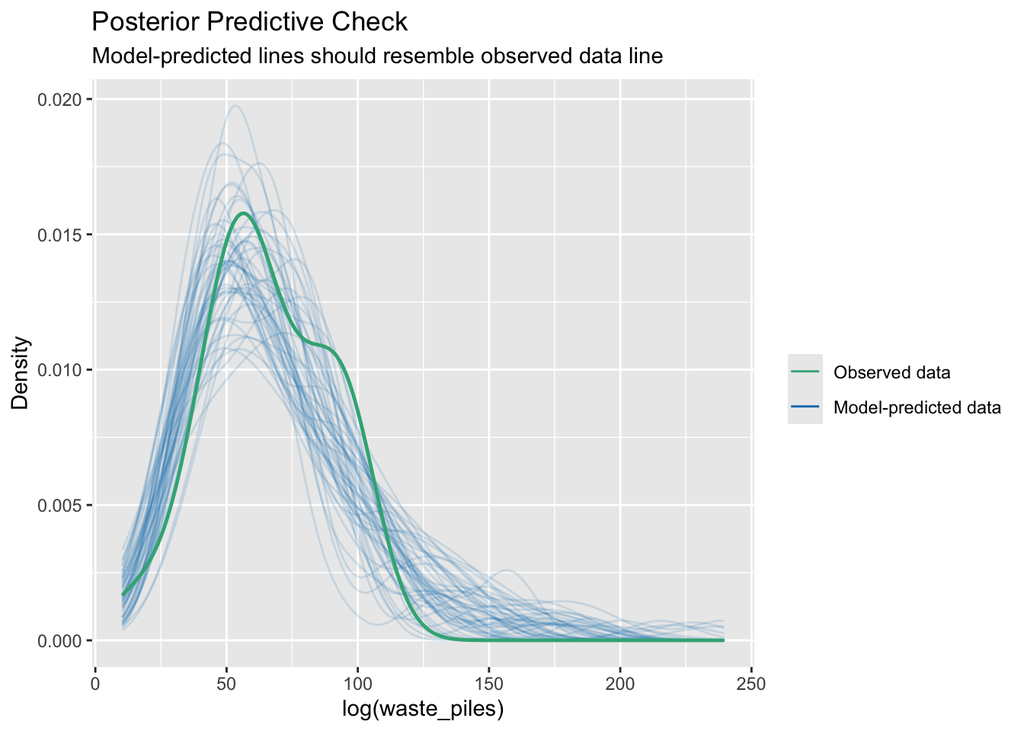

```r
check_predictions(m3_log, verbose = FALSE)
```

**Key takeaways:**

- The estimate produced using log-OLS are conveniently interpreted as the `percent change in the outcome`!
- Log-OLS is widely used in econometrics for count outcomes because it is simple and effective
- This model is popular due to its ease of interpretation and extensive documentation

### Comparing model output - Let’s take a look at the models we’ve estimated side-by-side

```r
export_summs(m1_ols, m2_poisson, m3_log,
             model.names = c("OLS","Poisson GLM","Log(Outcome) OLS"),
             statistics = "none")
```

|  | OLS | Poisson GLM | Log(Outcome) OLS |
| --- | --- | --- | --- |
| (Intercept) | 77.91 *** | 4.36 *** | 4.31 *** |
|  | (4.16) | (0.02) | (0.08) |
| treat | -24.77 *** | -0.38 *** | -0.42 *** |
|  | (5.88) | (0.04) | (0.12) |
| *** p < 0.001; ** p < 0.01; * p < 0.05. |  |  |  |

### Let’s do some quick math to compare treatment effect estimates

```r
# Calculate percent change in waste piles in each model:

m1_change = (-24.77/77.91)*100  ## % change = -31.8
m2_change = (exp(-.38) -1)*100  ## % change = -31.6
m3_change = (-0.42)*100         ## % change = -42
```

### Analysis check-in:

```
So far the log-OLS regression model is the best fitting model we have specified
```

**The treatment estimate for log-OLS can be interpret as follows:**

> *The model estimated that the treatment group had a 42% reduction in waste piles relative to the control group.*
- This estimate, however, is still not a robust causal effect (the OLS estimator is still a bit naive)
- Any ideas why this might be? - Discuss with you neighbor (Think. Pair. Share.)

### Let’s take a look at covariate balance across treatment conditions

```
Specifically, `pre_count_avg` (pre-treatment waste pile counts)
```

```r
post_treat_subset %>%
    select(treat, waste_piles, pre_count_avg) %>%
    tbl_summary(
        by = treat,
        statistic = list(all_continuous() ~ "{mean} ({sd})")) %>%
    modify_header(label ~ "**Variable**") %>%
    modify_spanning_header(c("stat_1", "stat_2") ~ "**Treatment**")
```

| **Variable** | **Treatment** **0** N = 22<sup>1</sup> | **Treatment** **1** N = 22<sup>1</sup> |
| --- | --- | --- |
| waste_piles | 78 (21) | 53 (18) |
| pre_count_avg | 94 (18) | 84 (26) |

<sup>1</sup> Mean (SD)

### Model 4: Moving towards casual inference

- Is this experiment a `Randomized Controlled Trial (RCT)`?
- Not quite - What about `selection bias/OVB`?
- Recall that the study researchers selected contiguous neighborhood pairs to compete in the intervention
- This assignment procedure could plausibly introduce selection bias (contaminating our treatment effect)
- It’s **always** important to check for balance on pre-treatment baseline characteristics (to check if randomization worked)
- Luckily, we can `control away` known sources of selection bias by adding `pre_count_avg` to the OLS model

```r
m4_control <- lm(
    log(waste_piles) ~
        treat +
        log(pre_count_avg), ## Add a control
    data = post_treat_subset)

summ(m4_control, model.fit = FALSE)
```

| Observations | 44 |
| --- | --- |
| Dependent variable | log(waste_piles) |
| Type | OLS linear regression |

|  | Est. | S.E. | t val. | p |
| --- | --- | --- | --- | --- |
| (Intercept) | 0.47 | 0.35 | 1.34 | 0.19 |
| treat | -0.27 | 0.06 | -4.44 | 0.00 |
| log(pre_count_avg) | 0.85 | 0.08 | 11.09 | 0.00 |

Standard errors: OLS

### Model 5: Does the enviroment stand still during our experiment?

**No!** We should account for events that might also affect trash burning during the treatment period

```
I.e., Anything else that might affect the number of trash piles burned (besides our treatment)
```

- Trash pile burning in these neighborhoods may vary by weather conditions
- Note: We will also switch to using `heteroskedasticity robust` standard errors (*more on this later!*)

### Look at balance across treatment conditions for average rain events

```r
post_treat_subset %>%
    select(treat, waste_piles, rain_0_48hrs, rain_49_168hrs) %>%
    tbl_summary(
        by = treat,
        statistic = list(all_continuous() ~ "{mean} ({sd})")) %>%
    modify_header(label ~ "**Variable**") %>%
    modify_spanning_header(c("stat_1", "stat_2") ~ "**Treatment**")
```

| **Variable** | **Treatment** **0** N = 22<sup>1</sup> | **Treatment** **1** N = 22<sup>1</sup> |
| --- | --- | --- |
| waste_piles | 78 (21) | 53 (18) |
| rain_0_48hrs | 0.18 (0.15) | 0.20 (0.16) |
| rain_49_168hrs | 0.17 (0.17) | 0.17 (0.17) |

<sup>1</sup> Mean (SD)

### Add controls for rain events during the competition period

```r
m5_control2 <- lm(
    log(waste_piles) ~
        treat +
        log(pre_count_avg) +
        rain_0_48hrs + rain_49_168hrs,
    data = post_treat_subset)

summ(m5_control2,
     model.fit = FALSE,
     robust = "HC2")  # Heteroskedasticity robust standard error adj.
```

| Observations | 44 |
| --- | --- |
| Dependent variable | log(waste_piles) |
| Type | OLS linear regression |

|  | Est. | S.E. | t val. | p |
| --- | --- | --- | --- | --- |
| (Intercept) | 0.43 | 0.45 | 0.95 | 0.35 |
| treat | -0.27 | 0.06 | -4.29 | 0.00 |
| log(pre_count_avg) | 0.86 | 0.07 | 12.51 | 0.00 |
| rain_0_48hrs | -0.02 | 0.85 | -0.03 | 0.98 |
| rain_49_168hrs | 0.07 | 0.79 | 0.09 | 0.93 |

Standard errors: Robust, type = HC2

### Comparing models after adding controls

```r
export_summs(m4_control, m5_control2, robust = "HC2",
             model.names = c("M4 - Pre-treat","M5 - Add Rain"),
             statistics = "none")
```

|  | M4 - Pre-treat | M5 - Add Rain |
| --- | --- | --- |
| (Intercept) | 0.47 | 0.43 |
|  | (0.33) | (0.45) |
| treat | -0.27 *** | -0.27 *** |
|  | (0.06) | (0.06) |
| log(pre_count_avg) | 0.85 *** | 0.86 *** |
|  | (0.07) | (0.07) |
| rain_0_48hrs |  | -0.02 |
|  |  | (0.85) |
| rain_49_168hrs |  | 0.07 |
|  |  | (0.79) |
| Standard errors are heteroskedasticity robust. *** p < 0.001; ** p < 0.01; * p < 0.05. |  |  |

### Model 6: Are neighborhoods `independent`?

- We have another issue which may bias our treatment effect - the neighborhoods were paired together
- We have to account for this `paired data` feature which is called `clustered data`
- **Why?** Clustered data violates the regression assumption that observations are `independent and identically distributed (i.i.d)`
- In-other-words, the data has within group `dependencies`, paired neighborhoods will likely be more similar than un-paired neighborhoods
- This structure of the data should be modeled

```r
m6_clust <- lm(
    log(waste_piles) ~
        treat +
        log(pre_count_avg) +
        rain_0_48hrs + rain_49_168hrs,
    data = post_treat_subset)

summ(m6_clust,
     robust = "HC2",
     cluster = "pair_id", # Add SE adj. based on pair-clusters
     model.fit = FALSE)
```

| Observations | 44 |
| --- | --- |
| Dependent variable | log(waste_piles) |
| Type | OLS linear regression |

|  | Est. | S.E. | t val. | p |
| --- | --- | --- | --- | --- |
| (Intercept) | 0.43 | 0.49 | 0.88 | 0.39 |
| treat | -0.27 | 0.07 | -3.63 | 0.00 |
| log(pre_count_avg) | 0.86 | 0.07 | 12.44 | 0.00 |
| rain_0_48hrs | -0.02 | 0.97 | -0.03 | 0.98 |
| rain_49_168hrs | 0.07 | 0.94 | 0.07 | 0.94 |

Standard errors: Cluster-robust, type = HC2

**Key takeaways:**

- Our treatment effect result is `robust` (remains unchanged) after adding the standard error adjustment
- **NOTE**: That the standard error (`SE`) is slightly more `conservative` (i.e., the SE increased)
- After accounting for dependencies by pair clusters the `SE` increased by .01
- However, our interpretation of the treatment effect remains unchanged
- The treatment was found to reduce waste pile burning by 27% (`p<.001`)

  Model `M6` replicates the treatment effect reported in Buntaine et al., 2024 (see Figure 2; T+6)

### Figure 2 adapted from Buntaine et al. (2024) - Replication of `T+6` treatment estimate

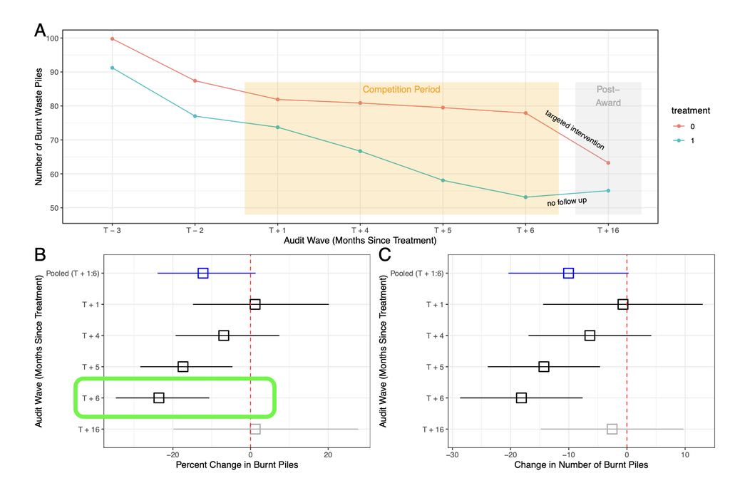

Source (Buntaine et al., 2024)